# CaM

Pablo Portillo Garrigues

17 de junio de 2018

## Basic Exploratory Analysis

```r
con <- file("en_US.blogs.txt","r")
lenn <- nchar(readLines(con))
length(lenn)
```

```
## [1] 899288
```

```r
max(lenn)
```

```
## [1] 40835
```

```r
sum(lenn)
```

```
## [1] 208361438
```

```r
close(con)
con <- file("en_US.news.txt","r")
lenn <- nchar(readLines(con))
length(lenn)
```

```
## [1] 77259
```

```r
max(lenn)
```

```
## [1] 5760
```

```r
sum(lenn)
```

```
## [1] 15683765
```

```r
close(con)
con <- file("en_US.twitter.txt","r")
lenn <- nchar(readLines(con))
length(lenn)
```

```
## [1] 2360148
```

```r
max(lenn)
```

```
## [1] 213
```

```r
sum(lenn)
```

```
## [1] 162384825
```

```r
close(con)
```

## Preparing the data

First of all we are going to merge the different text sources and randomize its rows. Once we have done it we are going to split the data in to 50% for training data and 50% for testing data. We are going to split the training data in 5 files

```r
if(!file.exists("trainTokData.txt")){
    if(!file.exists("unprocTrain1.txt")){
        if(!file.exists("randMergDat.txt")){
            datTwitter<-readLines("C:/Users/Pablo/Desktop/DataScienceStandford/Curso10/Proyecto/final/en_US/en_US.twitter.txt")
            datBlogs<-readLines("C:/Users/Pablo/Desktop/DataScienceStandford/Curso10/Proyecto/final/en_US/en_US.blogs.txt")
            datNews<-readLines("C:/Users/Pablo/Desktop/DataScienceStandford/Curso10/Proyecto/final/en_US/en_US.news.txt")
            datTot<-c(datTwitter,datBlogs,datNews)
            set.seed(1)
            datTot<-datTot[sample(length(datTot))]
            write(file="randMergDat.txt",datTot)
            rm(datTwitter,datBlogs,datNews,datTot)
        }
            dat<-readLines("randMergDat.txt")
            tam<-round(length(dat)/10)-1
            set.seed(2)
            train<-sample(1:10)[1:5]
            write(dat[(tam*train[1]-tam):(tam*train[1])],file="unprocTrain1.txt")
            write(dat[(tam*train[2]-tam):(tam*train[2])],file="unprocTrain2.txt")
            write(dat[(tam*train[3]-tam):(tam*train[3])],file="unprocTrain3.txt")
            write(dat[(tam*train[4]-tam):(tam*train[4])],file="unprocTrain4.txt")
            write(dat[(tam*train[5]-tam):(tam*train[5])],file="unprocTrain5.txt")


    }
}
```

## Processing Data

Now we are going to use the “tm” pachkage to make transformations. We will delete the non-ASCII words, make all the characters lower case, remove the stopwords, numbers, punctuation and profanity.

In order to process these transformation we have split the training data in 5 parts so we are going to perform these tranformations in each file.

Once we have performed it, we are going to tokenize the words in unigrams, bigrams, trigrams and quadgrams and write them in different files.

```r
if(!file.exists("uniG1.csv")){
archivos<-c("unprocTrain1.txt","unprocTrain2.txt","unprocTrain3.txt","unprocTrain4.txt","unprocTrain5.txt")
for(i in 1:5){
  conexion <- file(archivos[i], "r")
  texto <- readLines(conexion)
  close(conexion)
  texto<-gsub("[^ -~]","",texto)
  vs <- VectorSource(texto)
  cuerpo<-VCorpus(vs, readerControl=list(readPlain, language="en", load=TRUE))

cuerpoProc<-tm_map(cuerpo, content_transformer(tolower))
cuerpoProc<-tm_map(cuerpoProc, removeWords,
                           stopwords(kind="en"))
cuerpoProc<-tm_map(cuerpoProc, removePunctuation)
cuerpoProc<-tm_map(cuerpoProc, removeNumbers)
profanity<-readLines("profanity.txt")
cuerpoProc<-tm_map(cuerpoProc, removeWords,profanity)
dtmu<-DocumentTermMatrix(cuerpoProc)
dtmu<-slam::col_sums(dtmu, na.rm = T)
options(mc.cores=1)
bigramTokenizer <- function(x) {
    NGramTokenizer(x, Weka_control(min=2, max=2))
}

dtmb <- DocumentTermMatrix(cuerpoProc,control=list(tokenize=bigramTokenizer))
dtmb<-slam::col_sums(dtmb, na.rm = T)

trigramTokenizer <- function(x) {
    NGramTokenizer(x, Weka_control(min=3, max=3))
}

dtmt <- DocumentTermMatrix(cuerpoProc,control=list(tokenize=trigramTokenizer))
dtmt<-slam::col_sums(dtmt, na.rm = T)
dtmu<-sort(dtmu,decreasing = TRUE)

quadgramTokenizer <- function(x) {
    NGramTokenizer(x, Weka_control(min=4, max=4))
}

dtmq <- DocumentTermMatrix(cuerpoProc,control=list(tokenize=quadgramTokenizer))
dtmq<-slam::col_sums(dtmq, na.rm = T)
dtmq<-sort(dtmq,decreasing = TRUE)

df<-data.frame(values=dtmu,names=names(dtmu))
aux<-paste("uniG",i,".csv",sep="")
write.csv(file=aux,df)
dtmb<-sort(dtmb,decreasing = TRUE)
df<-data.frame(values=dtmb,names=names(dtmb))
aux<-paste("biG",i,".csv",sep="")
write.csv(file=aux,df)
dtmt<-sort(dtmt,decreasing = TRUE)
df<-data.frame(values=dtmt,names=names(dtmt))
aux<-paste("triG",i,".csv",sep="")
write.csv(file=aux,df)
df<-data.frame(values=dtmq,names=names(dtmq))
aux<-paste("quadG",i,".csv",sep="")
write.csv(file=aux,df)
}
}
```

## Basic statistics

Once we have merged the 5 files we are going to look for the 10 most used unigrams, bigrams, trigrams and quadgrams.

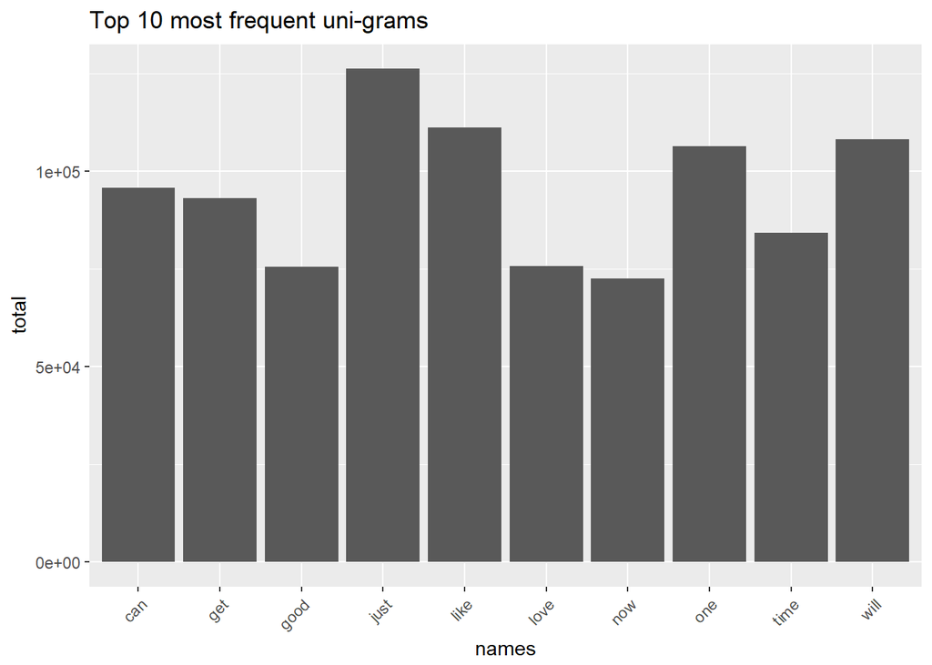

```r
dfut<-read.csv("uniGT.csv")[,-1]
dfut$names<-as.character(dfut$names)
dfut$total<-as.numeric(dfut$total)
g<- ggplot(data=dfut[1:10,],aes(x=names,y=total)) + geom_bar(stat="identity") +ggtitle("Top 10 most frequent uni-grams")+ theme(axis.text.x = element_text(angle = 45, hjust = 1))
plot(g)
```

[figure not shown]

```r
dfbt<-read.csv("biGT.csv")[,-1]
dfbt$names<-as.character(dfbt$names)
dfbt$total<-as.numeric(dfbt$total)
g <- ggplot(data=dfbt[1:10,],aes(x=names,y=total)) + geom_bar(stat="identity") +ggtitle("Top 10 most frequent uni-grams")+ theme(axis.text.x = element_text(angle = 45, hjust = 1))
plot(g)
```

[figure not shown]

```r
dftt<-read.csv("triGT.csv")[,-1]
dftt$names<-as.character(dftt$names)
dftt$total<-as.numeric(dftt$total)
g <- ggplot(data=dftt[1:10,],aes(x=names,y=total)) + geom_bar(stat="identity") +ggtitle("Top 10 most frequent uni-grams")+ theme(axis.text.x = element_text(angle = 45, hjust = 1))
plot(g)
```

[figure not shown]

```r
dfqt<-read.csv("quadGTr.csv")[,-1]
dfqt$names<-as.character(dfqt$names)
dfqt$total<-as.numeric(dfqt$total)
g <- ggplot(data=dfqt[1:10,],aes(x=names,y=total)) + geom_bar(stat="identity") +ggtitle("Top 10 most frequent uni-grams")+ theme(axis.text.x = element_text(angle = 45, hjust = 1))
plot(g)
```

[output not shown]